# Costly conversion data challenge

# Setup

The goal here is to evaluate whether a pricing test running on the site has been successful. As always, you should focus on user segmentation and provide insights about segments who behave differently as well as any other insights you might find.

# Quicklook results

- Fewer users convert when presented with the higher price.
- However, the test group has greater average revenue per person than the control group.
- Looking deeper at conversion rate
  - direct referal is a positive indicator of conversion rate
  - users directed by ads have a greater conversion rate than people directly accessing the site or led there by search engine optimzation
  - there is no difference in conversion rate between mobile and web users

# Import and inspect

The first step is importing the data

```r
if(!('pacman' %in% rownames(installed.packages()))) {
  install.packages('pacman')
}
library(pacman)

p_load(readr, janitor, here)
p_load(magrittr, dplyr, tidyr, lubridate, stringr, broom, purrr, forcats)
p_load(ggplot2, scales)
p_load(knitr, kableExtra, skimr, pander)
p_load(rsample, arm, rstan, brms, tidybayes)
p_load(parallel, future)

if(!file.exists('.here')) {
  set_here(path = getwd())
}

# summary constants
skim_with_defaults()

# plotting constants
theme_set(theme_bw())

# parallel processing w/ future
future::plan(multiprocess)
```

```r
user_info <- read_csv(here::here('user_table.csv')) %>% clean_names(.)
test_results <- read.csv(here::here('test_results.csv')) %>%
  as_tibble(.) %>%
  clean_names(.) %>%
  mutate(timestamp = as.character(timestamp),
         datetime = parse_datetime(timestamp))
```

```
## Warning: 5180 parsing failures.
## row col   expected              actual
##  55  -- valid date 2015-04-24 12:60:46
## 105  -- valid date 2015-04-24 11:60:20
## 122  -- valid date 2015-03-14 12:60:02
## 283  -- valid date 2015-05-11 12:60:53
## 288  -- valid date 2015-04-26 11:60:44
## ... ... .......... ...................
## See problems(...) for more details.
```

On initial import of the data, `read_csv()` returned a bunch of warnings regarding the `timestamp` column. Something hilarious that I found in the data is that over 5000 of the entries have an invalid datetime in the timestamp column. In all of these cases, as displayed by the warnings, the event occurs in minute 60. And that’s impossible, even with leap seconds.

There are two ways of handling these improperly formatted: ignoring them, or assume that the datetime counter failed to roll over. The former is much easier than the latter. Ignoring these entries, however, might have downstream problems – especially if they are biased in one direction (e.g. all from the experimental group).

## Summary table

But first, let’s quickly inspect the entire dateset to get an idea of missing data and distributions.

```r
skim(test_results) %>%
  pander()
```

Skim summary statistics  
n obs: 316800  
n variables: 9

| variable | missing | complete | n | min | max | empty | n_unique |
| --- | --- | --- | --- | --- | --- | --- | --- |
| timestamp | 0 | 316800 | 316800 | 19 | 19 | 0 | 140931 |

Table continues below

| variable | missing | complete | n | n_unique |
| --- | --- | --- | --- | --- |
| device | 0 | 316800 | 316800 | 2 |
| operative_system | 0 | 316800 | 316800 | 6 |
| source | 0 | 316800 | 316800 | 12 |

| top_counts | ordered |
| --- | --- |
| mob: 186471, web: 130329, NA: 0 | FALSE |
| win: 100976, iOS: 95465, and: 74935, mac: 25085 | FALSE |
| dir: 60357, ads: 59379, ads: 53396, ads: 29876 | FALSE |

Table continues below

| variable | missing | complete | n | mean | sd | p0 | p25 |
| --- | --- | --- | --- | --- | --- | --- | --- |
| converted | 0 | 316800 | 316800 | 0.018 | 0.13 | 0 | 0 |
| price | 0 | 316800 | 316800 | 46.21 | 9.6 | 39 | 39 |
| test | 0 | 316800 | 316800 | 0.36 | 0.48 | 0 | 0 |
| user_id | 0 | 316800 | 316800 | 5e+05 | 288591.15 | 3 | 249525.75 |

| p50 | p75 | p100 | hist |
| --- | --- | --- | --- |
| 0 | 0 | 1 | ▇▁▁▁▁▁▁▁ |
| 39 | 59 | 59 | ▇▁▁▁▁▁▁▅ |
| 0 | 1 | 1 | ▇▁▁▁▁▁▁▅ |
| 5e+05 | 749025.5 | 1e+06 | ▇▇▇▇▇▇▇▇ |

Table continues below

| variable | missing | complete | n | min | max | median |
| --- | --- | --- | --- | --- | --- | --- |
| datetime | 5180 | 311620 | 316800 | 2015-03-02 | 2015-05-31 | 2015-04-17 |

| n_unique |
| --- |
| 138662 |

Turns out there isn’t any missing data, except that introduced creating the `datetime` column.

Let’s visualize if the invalid date times in the `timestamp` column are associated with one of the experimental classes for than the other.

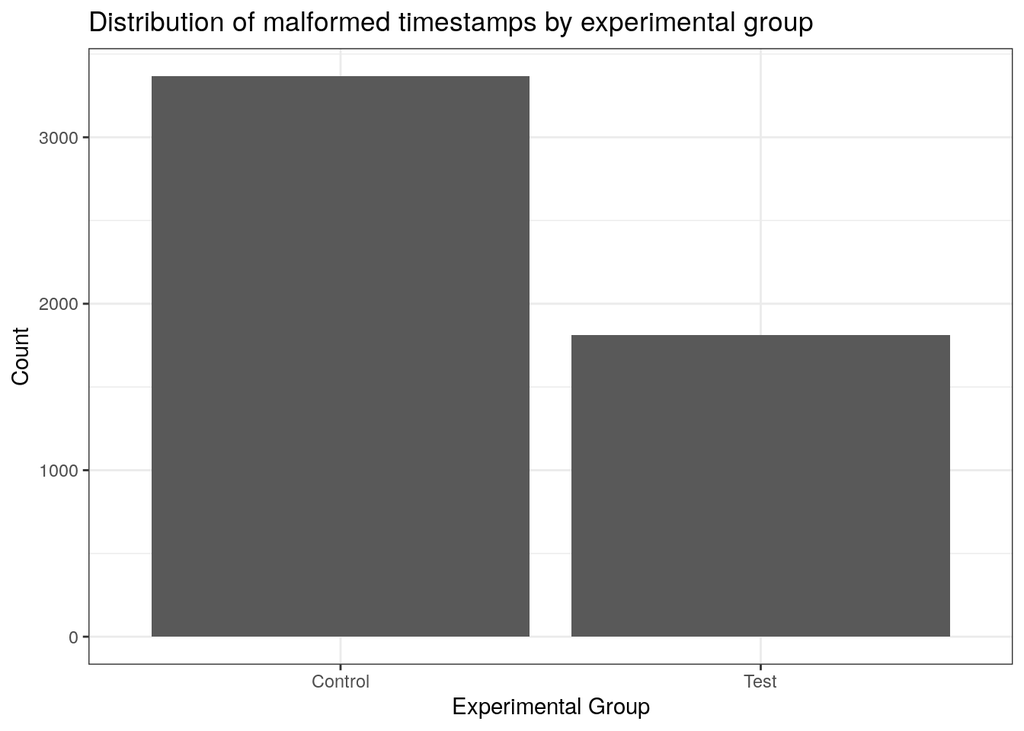

```r
missing_results <-
  test_results %>%
  dplyr::select(datetime, test, converted) %>%
  filter(is.na(datetime)) %>%
  mutate(test_name = case_when(test == 0 ~ 'Control',
                               test == 1 ~ 'Test'),
         converted_name = case_when(converted == 1 ~ 'Bought',
                                    converted == 0 ~ 'Did not buy'))

missing_results %>%
  ggplot(aes(x = factor(test_name))) +
  geom_bar() +
  labs(x = 'Experimental Group',
       y = 'Count',
       title = 'Distribution of malformed timestamps by experimental group')
```

Given that we know two-thirds of our data is from the Control group and one-third of our data is from the Test group, the above graph appears to indicate that these malformed timestamps are randomly distributed wrt the experiment.

But are these malformed dates structured by if the user “converted” or not?

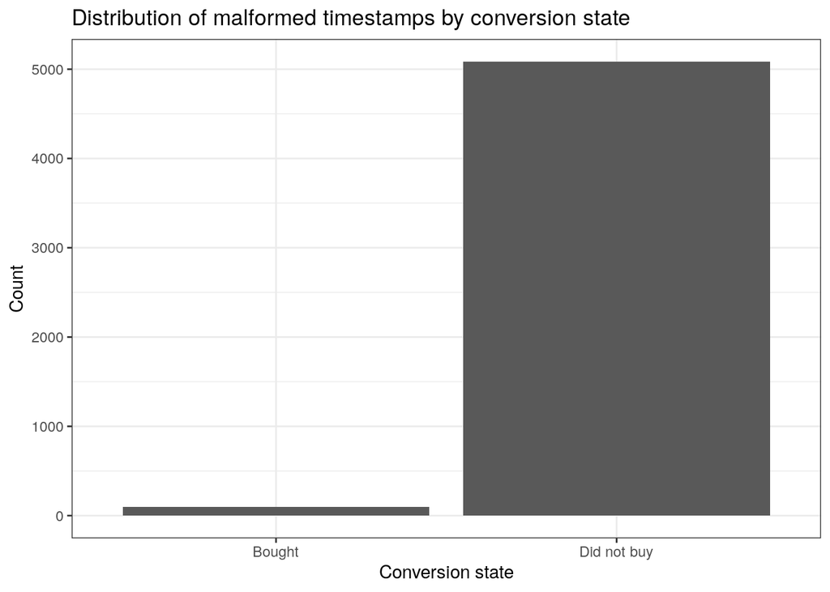

```r
missing_results %>%
  ggplot(aes(x = factor(converted_name))) +
  geom_bar() +
  labs(x = 'Conversion state',
       y = 'Count',
       title = 'Distribution of malformed timestamps by conversion state')
```

Most of our malformed timestamps are from users that did not end up buying the product. Would we expect that given the distribution of conversions?

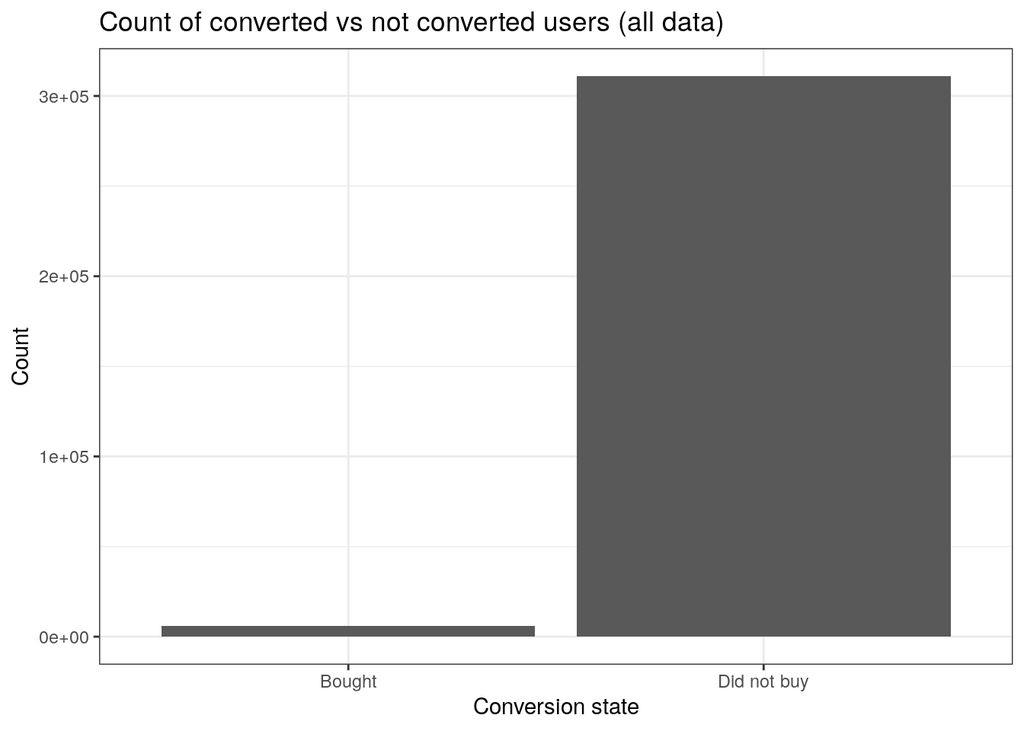

```r
test_results %>%
  mutate(converted_name = case_when(converted == 1 ~ 'Bought',
                                    converted == 0 ~ 'Did not buy')) %>%
  ggplot(aes(x = converted_name)) +
  geom_bar() +
  labs(x = 'Conversion state',
       y = 'Count',
       title = 'Count of converted vs not converted users (all data)')
```

Probably. So there is probably not immediate cause for concern.

# Looking at experimental results

## Basic comparison

We want to know if the test group has a greater conversion rate than the control group. Our response is the `converted` column. We can explore conversion as predicted by test by building a two-way table. In this case, we do not need to drop the observations with missing timestamps.

```r
conversion_table <-
  test_results %>%
  dplyr::select(test, converted) %>%
  transmute(Experiment = case_when(test == 1 ~ 'Test',
                                   test == 0 ~ 'Control'),
            Result = case_when(converted == 1 ~ 'Bought',
                               converted == 0 ~ 'Did not buy')) %>%
  tabyl(Experiment, Result)

conversion_table %>%
  adorn_totals(c('row', 'col')) %>%
  adorn_percentages('row') %>%
  adorn_pct_formatting(rounding = "half up", digits = 2) %>%
  adorn_ns() %>%
  adorn_title('Conversion results for experiment (all data)',
              placement = 'top') %>%
  knitr::kable() %>%
  kableExtra::kable_styling()
```

|  | Result |  |  |
| --- | --- | --- | --- |
| Conversion results for experiment (all data) | Bought | Did not buy | Total |
| Control | 1.99% (4035) | 98.01% (198692) | 100.00% (202727) |
| Test | 1.55% (1773) | 98.45% (112300) | 100.00% (114073) |
| Total | 1.83% (5808) | 98.17% (310992) | 100.00% (316800) |

```r
conversion_table %>%
  chisq.test() %>%
  tidy()
```

```
## # A tibble: 1 x 4
##   statistic  p.value parameter method
##       <dbl>    <dbl>     <int> <chr>
## 1      76.9 1.80e-18         1 Pearson's Chi-squared test with Yates' continuity correction
```

A $\chi^{2}$ test (displayed) might be the appropriate here: we are testing to see if there is a significant difference between the expected frequencies and the observed frequencies in the two-way table. Given this, we might say that the test group is converting at a lower rate than the control group. However, this test doesn’t deal with differences in revenue created by the new group or if there is an increase or decrease in conversion based on the testing group.

Regardless, the results of the $\chi^{2}$ test indicate that there is a significant difference between the test and control groups. Based on the distribution of counts in the two-way table, a smaller percentage of the test group is converting than the control group.

But is that meaningful for our question? What about revenue? What about different segments of the user base? Currently, I’ve only considered the user base as a whole.

## Revenue differential

Ok, so the test group converts less often. But is the company earning more money, on average, from the testing group than the control group?

```r
test_results  %>%
  group_by(test) %>%
  mutate(paid = price * converted) %>%
  summarize(earn = sum(paid),
            earn_avg = earn / n())
```

```
## # A tibble: 2 x 3
##    test   earn earn_avg
##   <int>  <int>    <dbl>
## 1     0 157465    0.777
## 2     1 104587    0.917
```

This simple summary implies that average earning per test user is slightly higher than that earned from the control group. However, these individual values aren’t very useful – how do we know if this difference between the groups is real?

One approach is to use bootstrap resampling to give confidence intervals on these estimates.

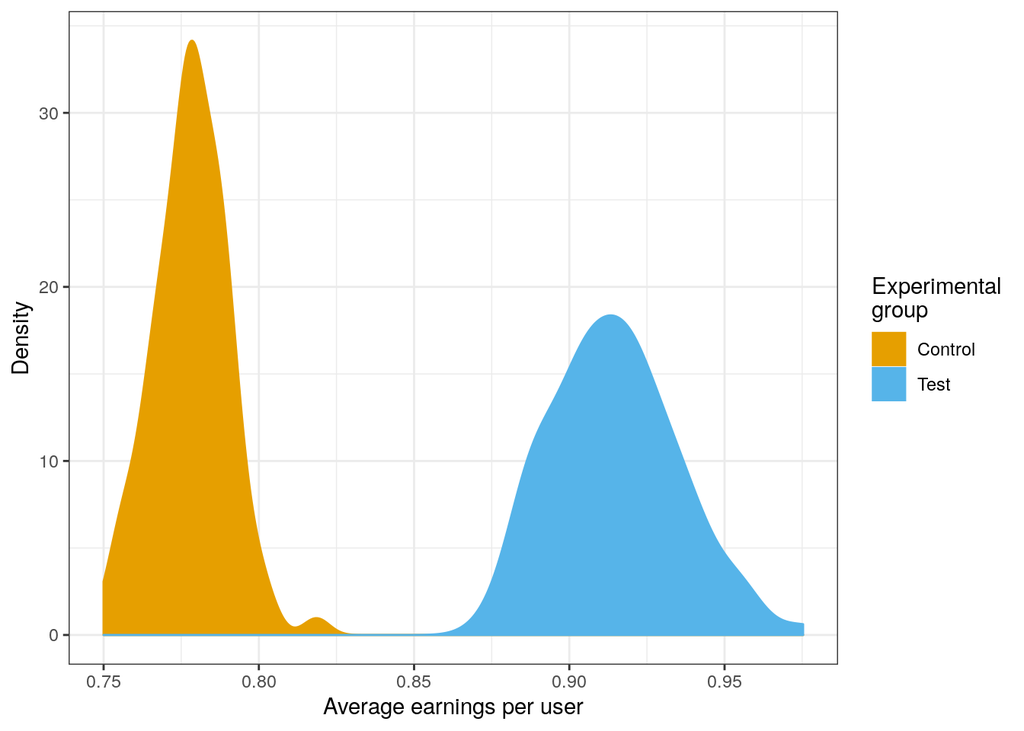

```r
get_earn_avg <- function(split) {
  as.data.frame(split) %>%
    group_by(test) %>%
    mutate(paid = price * converted) %>%
    summarize(earn_avg = sum(paid) / n())
}

boot_res <-
  test_results %>%
  bootstraps(., times = 100, strata = test) %>%
  transmute(sum_stat = purrr::map(splits, get_earn_avg)) %>%
  unnest(cols = c(sum_stat))

boot_res %>%
  mutate(test_name = case_when(test == 0 ~ 'Control',
                               test == 1 ~ 'Test')) %>%
  ggplot(aes(x = earn_avg,
             group = test_name,
             colour = test_name,
             fill = test_name)) +
  geom_density() +
  scale_fill_manual(values = c("#E69F00", "#56B4E9")) +
  scale_colour_manual(values = c("#E69F00", "#56B4E9")) +
  labs(x = 'Average earnings per user',
       y = 'Density',
       labs = 'Bootstrap estimates of Average earnings per user, by test group',
       colour = 'Experimental\ngroup',
       fill = 'Experimental\ngroup')
```

Given the lack of overlap between these two distributions, I conclude that even though the test group coverts less often than the control group, the average earnings per user is greater.

# Conversion by segment

Let’s see if there is a particular demographic that is most affected by the A/B test. For example, do mobile users convert at a greater rate than web users? I’m going to use device and source as additional predictors.

Before I can use source as a predictor, I’m going to simplify the space a little – I’m just going to compare e.g. ads versus seo and assume that the type of source is mostly noise.

```r
test_results %<>%
  mutate(source = str_replace(source, '-', '_'),
         source_simple = str_extract(source, pattern = '^[^_]+(?=_)'))
```

I’m going to model this data using logistic regression with a series of categorical predictors. In particular, I’m using Bayesian logistic regression to so I can use weakly informative to lightly regularize the regression coefficient estimates. Additionally, by using `brms` I can extract the underlying Stan code, which can be compiled into a C++ module or even used in other programming languages like python. This means my exploration can lead directly to production.

With any Bayesian model, there are always questions surrounding choice of prior. I’m opting for weakly informative priors that are informed by the properties of the logistic function. Coefficients with magnitude greater than 2 are unlikely, and an intercept with magnitude greater than 5 are extremely unlikely. However, I’m going to use a slighly weaker prior for the intercept because it can be hard to predict its behaviour in the presence of predictors. Additionally, by lightly concentrating the density of the prior around 0, high magnitude posterior estimates will be slightly shrunk towards 0. I do not have any more domain knowledge about the problem, so I’m sticking with these rather general priors.

I do not need to explicitly dummy code out the categorical variables as R and `brms` take care of that under the hood.

Also, before I fit the model, I should probably split the data into test and training sets.

```r
results_split <-
  test_results %>%
  initial_split(prop = 0.8, strata = converted)

results_train <- training(results_split)
results_test <- testing(results_split)
```

Now to fit a model.

```r
model_1 <-
  results_train %>%
  brm(data = .,
      family = bernoulli(),
      formula = bf(converted ~ test + device + source_simple),
      prior = c(prior(normal(0, 5), class = 'Intercept'),
                prior(normal(0, 1), class = 'b')),
      iter = 2000,
      warmup = 1000,
      chains = 4,
      refresh = 0,
      future = TRUE)                   # parallel processing via future
```

```r
summary(model_1)
```

```
##  Family: bernoulli
##   Links: mu = logit
## Formula: converted ~ test + device + source_simple
##    Data: . (Number of observations: 253441)
## Samples: 4 chains, each with iter = 2000; warmup = 1000; thin = 1;
##          total post-warmup samples = 4000
##
## Population-Level Effects:
##                     Estimate Est.Error l-95% CI u-95% CI Rhat Bulk_ESS Tail_ESS
## Intercept              -3.89      0.03    -3.94    -3.84 1.00     5416     3175
## test                   -0.27      0.03    -0.33    -0.21 1.00     5781     2804
## deviceweb              -0.03      0.03    -0.09     0.03 1.00     5706     3301
## source_simpledirect    -0.36      0.04    -0.45    -0.27 1.00     5006     2645
## source_simplefriend     0.80      0.05     0.72     0.89 1.00     4732     3066
## source_simpleseo       -0.11      0.04    -0.20    -0.04 1.00     4866     3137
##
## Samples were drawn using sampling(NUTS). For each parameter, Eff.Sample
## is a crude measure of effective sample size, and Rhat is the potential
## scale reduction factor on split chains (at convergence, Rhat = 1).
```

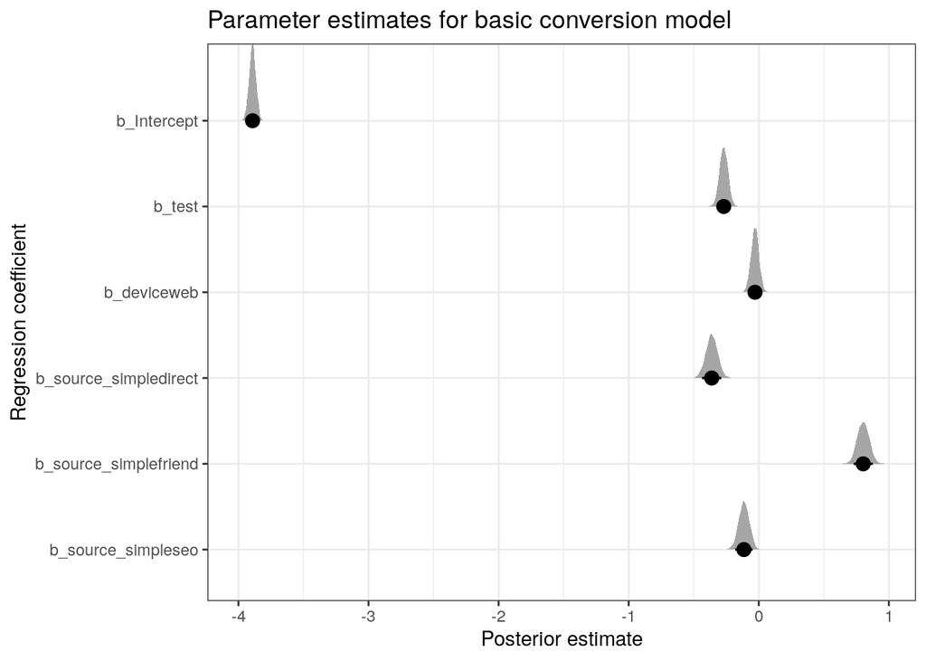

```r
model_1 %>%
  tidy_draws() %>%
  dplyr::select(-(.chain:.draw), -(lp__:energy__)) %>%
  gather(key = key, value = value) %>%
  mutate(key = fct_inorder(key),
         key = fct_rev(key)) %>%
  ggplot(aes(x = value, y = key)) +
  geom_halfeyeh(.width = c(0.9, 0.5)) +
  labs(x = 'Posterior estimate',
       y = 'Regression coefficient',
       title = 'Parameter estimates for basic conversion model')
```

Our intercept is a very negative number on the logit scale. Interpreted as a probability, the median posterior probability of a user converting when that user is in the control group, on a mobile device and directed to the site via an add is 0.02. With unbalanced classes, logistic regression can have trouble predicting the state of new observations because the intercept term is too negative or positive.

As we learned earlier, the test group has a lower probability of converting than the control group. My guess is that the increased price turns people off.

Additionally, the device has no effect on conversion probability.

Interestingly, relative to ads, a user coming to the site via a friend’s recomendation is the greatest predictor of a user actually converting. In contrast, direct traffic or search engine optimzation appears to decrease probability of converting relative to being directed via an ad.

## Test data

All of this, however, still hasn’t answered the question of how **revenue** may have changed in the test group versus the control.